# Risk Factor Analysis

## Outcome Variable

**Outcome Variable:** stunted

## Predictor Variables

**Intervention Variable:** mwtkg

**Adjustment Set:**

unadjusted

## Stratifying Variables

The analysis was stratified on these variable(s):

- agecat
- studyid

The following strata were considered:

- agecat: 12 months, studyid: ki0047075b-MAL-ED
- agecat: 12 months, studyid: ki1017093-NIH-Birth
- agecat: 12 months, studyid: ki1017093b-PROVIDE
- agecat: 12 months, studyid: ki1017093c-NIH-Crypto
- agecat: 12 months, studyid: ki1066203-TanzaniaChild2
- agecat: 12 months, studyid: ki1126311-ZVITAMBO
- agecat: 12 months, studyid: ki1148112-LCNI-5
- agecat: 18 months, studyid: ki0047075b-MAL-ED
- agecat: 18 months, studyid: ki1017093-NIH-Birth
- agecat: 18 months, studyid: ki1017093b-PROVIDE
- agecat: 18 months, studyid: ki1017093c-NIH-Crypto
- agecat: 18 months, studyid: ki1066203-TanzaniaChild2
- agecat: 18 months, studyid: ki1126311-ZVITAMBO
- agecat: 18 months, studyid: ki1148112-LCNI-5
- agecat: 24 months, studyid: ki0047075b-MAL-ED
- agecat: 24 months, studyid: ki1017093-NIH-Birth
- agecat: 24 months, studyid: ki1017093b-PROVIDE
- agecat: 24 months, studyid: ki1017093c-NIH-Crypto
- agecat: 24 months, studyid: ki1066203-TanzaniaChild2
- agecat: 24 months, studyid: ki1126311-ZVITAMBO
- agecat: 24 months, studyid: ki1148112-LCNI-5
- agecat: 3 months, studyid: ki0047075b-MAL-ED
- agecat: 3 months, studyid: ki1017093-NIH-Birth
- agecat: 3 months, studyid: ki1017093b-PROVIDE
- agecat: 3 months, studyid: ki1017093c-NIH-Crypto
- agecat: 3 months, studyid: ki1066203-TanzaniaChild2
- agecat: 3 months, studyid: ki1126311-ZVITAMBO
- agecat: 6 months, studyid: ki0047075b-MAL-ED
- agecat: 6 months, studyid: ki1017093-NIH-Birth
- agecat: 6 months, studyid: ki1017093b-PROVIDE
- agecat: 6 months, studyid: ki1017093c-NIH-Crypto
- agecat: 6 months, studyid: ki1066203-TanzaniaChild2
- agecat: 6 months, studyid: ki1126311-ZVITAMBO
- agecat: 6 months, studyid: ki1148112-LCNI-5
- agecat: 9 months, studyid: ki0047075b-MAL-ED
- agecat: 9 months, studyid: ki1017093-NIH-Birth
- agecat: 9 months, studyid: ki1017093b-PROVIDE
- agecat: 9 months, studyid: ki1017093c-NIH-Crypto
- agecat: 9 months, studyid: ki1066203-TanzaniaChild2
- agecat: 9 months, studyid: ki1126311-ZVITAMBO
- agecat: 9 months, studyid: ki1148112-LCNI-5
- agecat: Birth, studyid: ki0047075b-MAL-ED
- agecat: Birth, studyid: ki1017093-NIH-Birth
- agecat: Birth, studyid: ki1017093c-NIH-Crypto
- agecat: Birth, studyid: ki1126311-ZVITAMBO

### Dropped Strata

Some strata were dropped due to rare outcomes:

- agecat: 12 months, studyid: ki1017093b-PROVIDE
- agecat: 12 months, studyid: ki1066203-TanzaniaChild2
- agecat: 18 months, studyid: ki1066203-TanzaniaChild2
- agecat: 18 months, studyid: ki1126311-ZVITAMBO
- agecat: 24 months, studyid: ki1017093b-PROVIDE
- agecat: 24 months, studyid: ki1066203-TanzaniaChild2
- agecat: 24 months, studyid: ki1126311-ZVITAMBO
- agecat: 3 months, studyid: ki1017093b-PROVIDE
- agecat: 3 months, studyid: ki1066203-TanzaniaChild2
- agecat: 6 months, studyid: ki1017093b-PROVIDE
- agecat: 6 months, studyid: ki1066203-TanzaniaChild2
- agecat: 9 months, studyid: ki1017093b-PROVIDE
- agecat: 9 months, studyid: ki1066203-TanzaniaChild2
- agecat: Birth, studyid: ki1017093-NIH-Birth
- agecat: Birth, studyid: ki1017093c-NIH-Crypto
- agecat: Birth, studyid: ki1126311-ZVITAMBO

## Methods Detail

We’re interested in the causal parameters $E[Y_a]$ for all values of $a \in \mathcal{A}$. These parameters represent the mean outcome if, possibly contrary to fact, we intervened to set all units to have $A=a$. Under the randomization and positivity assumptions, these are identified by the statistical parameters $\psi_a=E_W[E_{Y|A,W}(Y|A=a,W)]$. In addition, we’re interested in the mean of $Y$, $E[Y]$ under no intervention (the observed mean). We will estimate these parameters by using SuperLearner to fit the relevant likelihood factors – $E_{Y|A,W}(Y|A=a,W)$ and $p(A=a|W)$, and then updating our likelihood fit using a joint TMLE.

For unadjusted analyses ($W=\{\}$), initial likelihoods were estimated using Lrnr_glm to estimate the simple $E(Y|A)$ and Lrnr_mean to estimate $p(A)$. For adjusted analyses, a small library containing Lrnr_glmnet, Lrnr_xgboost, and Lrnr_mean was used.

Having estimated these parameters, we will then use the delta method to estimate relative risks and attributable risks relative to a prespecified baseline level of $A$.

# Results Detail

## Results Plots

[figure not shown]

[figure not shown]

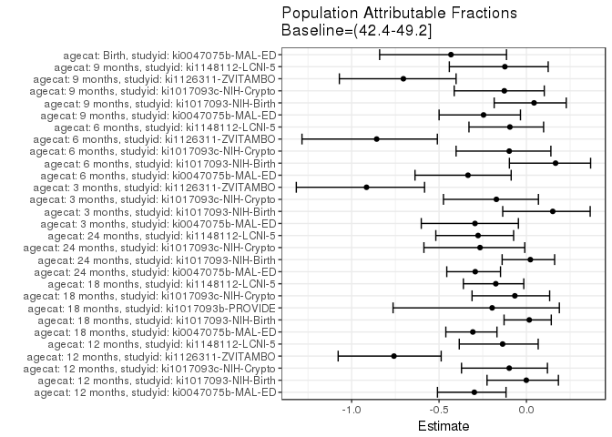

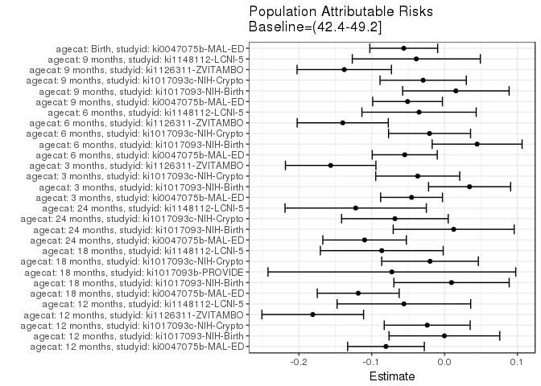

## Data Summary

| agecat | studyid | A | n | nA | nAY0 | nAY1 |
| --- | --- | --- | --- | --- | --- | --- |
| 12 months | ki0047075b-MAL-ED | (42.4-49.2] | 1609 | 317 | 206 | 111 |
| 12 months | ki0047075b-MAL-ED | (49.2-59.3] | 1609 | 597 | 436 | 161 |
| 12 months | ki0047075b-MAL-ED | <=42.4 | 1609 | 131 | 79 | 52 |
| 12 months | ki0047075b-MAL-ED | >59.3 | 1609 | 564 | 454 | 110 |
| 12 months | ki1017093-NIH-Birth | (42.4-49.2] | 491 | 160 | 100 | 60 |
| 12 months | ki1017093-NIH-Birth | (49.2-59.3] | 491 | 142 | 106 | 36 |
| 12 months | ki1017093-NIH-Birth | <=42.4 | 491 | 138 | 60 | 78 |
| 12 months | ki1017093-NIH-Birth | >59.3 | 491 | 51 | 41 | 10 |
| 12 months | ki1017093b-PROVIDE | (42.4-49.2] | 153 | 39 | 26 | 13 |
| 12 months | ki1017093b-PROVIDE | (49.2-59.3] | 153 | 51 | 44 | 7 |
| 12 months | ki1017093b-PROVIDE | <=42.4 | 153 | 37 | 16 | 21 |
| 12 months | ki1017093b-PROVIDE | >59.3 | 153 | 26 | 23 | 3 |
| 12 months | ki1017093c-NIH-Crypto | (42.4-49.2] | 706 | 218 | 160 | 58 |
| 12 months | ki1017093c-NIH-Crypto | (49.2-59.3] | 706 | 248 | 193 | 55 |
| 12 months | ki1017093c-NIH-Crypto | <=42.4 | 706 | 97 | 58 | 39 |
| 12 months | ki1017093c-NIH-Crypto | >59.3 | 706 | 143 | 124 | 19 |
| 12 months | ki1066203-TanzaniaChild2 | (42.4-49.2] | 349 | 34 | 25 | 9 |
| 12 months | ki1066203-TanzaniaChild2 | (49.2-59.3] | 349 | 132 | 112 | 20 |
| 12 months | ki1066203-TanzaniaChild2 | <=42.4 | 349 | 4 | 4 | 0 |
| 12 months | ki1066203-TanzaniaChild2 | >59.3 | 349 | 179 | 156 | 23 |
| 12 months | ki1126311-ZVITAMBO | (42.4-49.2] | 1642 | 193 | 112 | 81 |
| 12 months | ki1126311-ZVITAMBO | (49.2-59.3] | 1642 | 696 | 514 | 182 |
| 12 months | ki1126311-ZVITAMBO | <=42.4 | 1642 | 12 | 5 | 7 |
| 12 months | ki1126311-ZVITAMBO | >59.3 | 1642 | 741 | 619 | 122 |
| 12 months | ki1148112-LCNI-5 | (42.4-49.2] | 310 | 116 | 62 | 54 |
| 12 months | ki1148112-LCNI-5 | (49.2-59.3] | 310 | 138 | 90 | 48 |
| 12 months | ki1148112-LCNI-5 | <=42.4 | 310 | 27 | 9 | 18 |
| 12 months | ki1148112-LCNI-5 | >59.3 | 310 | 29 | 22 | 7 |
| 18 months | ki0047075b-MAL-ED | (42.4-49.2] | 1540 | 307 | 152 | 155 |
| 18 months | ki0047075b-MAL-ED | (49.2-59.3] | 1540 | 574 | 349 | 225 |

[output cut: 166 more lines]

## Results Table

### Parameter: TSM

| agecat | studyid | intervention_level | baseline_level | estimate | ci_lower | ci_upper |
| --- | --- | --- | --- | --- | --- | --- |
| 12 months | ki0047075b-MAL-ED | (42.4-49.2] | NA | 0.3501577 | 0.2976299 | 0.4026855 |
| 12 months | ki0047075b-MAL-ED | (49.2-59.3] | NA | 0.2696817 | 0.2340713 | 0.3052922 |
| 12 months | ki0047075b-MAL-ED | <=42.4 | NA | 0.3969466 | 0.3131374 | 0.4807557 |
| 12 months | ki0047075b-MAL-ED | >59.3 | NA | 0.1950355 | 0.1623248 | 0.2277461 |
| 12 months | ki1017093-NIH-Birth | (42.4-49.2] | NA | 0.3750000 | 0.2999092 | 0.4500908 |
| 12 months | ki1017093-NIH-Birth | (49.2-59.3] | NA | 0.2535211 | 0.1818965 | 0.3251458 |
| 12 months | ki1017093-NIH-Birth | <=42.4 | NA | 0.5652174 | 0.4824241 | 0.6480107 |
| 12 months | ki1017093-NIH-Birth | >59.3 | NA | 0.1960784 | 0.0870029 | 0.3051540 |
| 12 months | ki1017093c-NIH-Crypto | (42.4-49.2] | NA | 0.2660550 | 0.2073541 | 0.3247560 |
| 12 months | ki1017093c-NIH-Crypto | (49.2-59.3] | NA | 0.2217742 | 0.1700328 | 0.2735156 |
| 12 months | ki1017093c-NIH-Crypto | <=42.4 | NA | 0.4020619 | 0.3044181 | 0.4997056 |
| 12 months | ki1017093c-NIH-Crypto | >59.3 | NA | 0.1328671 | 0.0771948 | 0.1885395 |
| 12 months | ki1126311-ZVITAMBO | (42.4-49.2] | NA | 0.4196891 | 0.3500432 | 0.4893351 |
| 12 months | ki1126311-ZVITAMBO | (49.2-59.3] | NA | 0.2614943 | 0.2288367 | 0.2941518 |
| 12 months | ki1126311-ZVITAMBO | <=42.4 | NA | 0.5833333 | 0.3043087 | 0.8623580 |
| 12 months | ki1126311-ZVITAMBO | >59.3 | NA | 0.1646424 | 0.1379321 | 0.1913526 |
| 12 months | ki1148112-LCNI-5 | (42.4-49.2] | NA | 0.4655172 | 0.3745981 | 0.5564364 |
| 12 months | ki1148112-LCNI-5 | (49.2-59.3] | NA | 0.3478261 | 0.2682334 | 0.4274187 |
| 12 months | ki1148112-LCNI-5 | <=42.4 | NA | 0.6666667 | 0.4885676 | 0.8447657 |
| 12 months | ki1148112-LCNI-5 | >59.3 | NA | 0.2413793 | 0.0853835 | 0.3973752 |
| 18 months | ki0047075b-MAL-ED | (42.4-49.2] | NA | 0.5048860 | 0.4489400 | 0.5608320 |
| 18 months | ki0047075b-MAL-ED | (49.2-59.3] | NA | 0.3919861 | 0.3520353 | 0.4319368 |
| 18 months | ki0047075b-MAL-ED | <=42.4 | NA | 0.6000000 | 0.5140908 | 0.6859092 |
| 18 months | ki0047075b-MAL-ED | >59.3 | NA | 0.2621723 | 0.2248568 | 0.2994878 |
| 18 months | ki1017093-NIH-Birth | (42.4-49.2] | NA | 0.5779221 | 0.4998334 | 0.6560108 |
| 18 months | ki1017093-NIH-Birth | (49.2-59.3] | NA | 0.4887218 | 0.4036763 | 0.5737673 |
| 18 months | ki1017093-NIH-Birth | <=42.4 | NA | 0.7890625 | 0.7183094 | 0.8598156 |
| 18 months | ki1017093-NIH-Birth | >59.3 | NA | 0.3541667 | 0.2187223 | 0.4896111 |
| 18 months | ki1017093b-PROVIDE | (42.4-49.2] | NA | 0.4411765 | 0.2736831 | 0.6086699 |
| 18 months | ki1017093b-PROVIDE | (49.2-59.3] | NA | 0.2083333 | 0.0930349 | 0.3236318 |

[output cut: 86 more lines]

### Parameter: E(Y)

| agecat | studyid | intervention_level | baseline_level | estimate | ci_lower | ci_upper |
| --- | --- | --- | --- | --- | --- | --- |
| 12 months | ki0047075b-MAL-ED | NA | NA | 0.2697328 | 0.2664366 | 0.2730289 |
| 12 months | ki1017093-NIH-Birth | NA | NA | 0.3747454 | 0.3629449 | 0.3865459 |
| 12 months | ki1017093c-NIH-Crypto | NA | NA | 0.2422096 | 0.2363717 | 0.2480475 |
| 12 months | ki1126311-ZVITAMBO | NA | NA | 0.2387333 | 0.2345674 | 0.2428991 |
| 12 months | ki1148112-LCNI-5 | NA | NA | 0.4096774 | 0.3978399 | 0.4215150 |
| 18 months | ki0047075b-MAL-ED | NA | NA | 0.3863636 | 0.3809216 | 0.3918057 |
| 18 months | ki1017093-NIH-Birth | NA | NA | 0.5874730 | 0.5746714 | 0.6002746 |
| 18 months | ki1017093b-PROVIDE | NA | NA | 0.3687943 | 0.3395528 | 0.3980359 |
| 18 months | ki1017093c-NIH-Crypto | NA | NA | 0.3012618 | 0.2938232 | 0.3087004 |
| 18 months | ki1148112-LCNI-5 | NA | NA | 0.4915730 | 0.4795096 | 0.5036365 |
| 24 months | ki0047075b-MAL-ED | NA | NA | 0.3749157 | 0.3693626 | 0.3804688 |
| 24 months | ki1017093-NIH-Birth | NA | NA | 0.5547786 | 0.5420451 | 0.5675120 |
| 24 months | ki1017093c-NIH-Crypto | NA | NA | 0.2568093 | 0.2481357 | 0.2654829 |
| 24 months | ki1148112-LCNI-5 | NA | NA | 0.4410774 | 0.4268139 | 0.4553410 |
| 3 months | ki0047075b-MAL-ED | NA | NA | 0.1540648 | 0.1522789 | 0.1558507 |
| 3 months | ki1017093-NIH-Birth | NA | NA | 0.2280702 | 0.2228239 | 0.2333164 |
| 3 months | ki1017093c-NIH-Crypto | NA | NA | 0.2142857 | 0.2098078 | 0.2187637 |
| 3 months | ki1126311-ZVITAMBO | NA | NA | 0.1709040 | 0.1676488 | 0.1741591 |
| 6 months | ki0047075b-MAL-ED | NA | NA | 0.1635071 | 0.1613126 | 0.1657016 |
| 6 months | ki1017093-NIH-Birth | NA | NA | 0.2681564 | 0.2592325 | 0.2770804 |
| 6 months | ki1017093c-NIH-Crypto | NA | NA | 0.2097902 | 0.2048671 | 0.2147133 |
| 6 months | ki1126311-ZVITAMBO | NA | NA | 0.1631098 | 0.1600830 | 0.1661365 |
| 6 months | ki1148112-LCNI-5 | NA | NA | 0.3701923 | 0.3608701 | 0.3795145 |
| 9 months | ki0047075b-MAL-ED | NA | NA | 0.2069810 | 0.2043589 | 0.2096031 |
| 9 months | ki1017093-NIH-Birth | NA | NA | 0.3570020 | 0.3491641 | 0.3648399 |
| 9 months | ki1017093c-NIH-Crypto | NA | NA | 0.2322946 | 0.2261039 | 0.2384854 |
| 9 months | ki1126311-ZVITAMBO | NA | NA | 0.1956173 | 0.1926059 | 0.1986288 |
| 9 months | ki1148112-LCNI-5 | NA | NA | 0.3146417 | 0.3031999 | 0.3260836 |
| Birth | ki0047075b-MAL-ED | NA | NA | 0.1298246 | 0.1274493 | 0.1321998 |

### Parameter: RR

| agecat | studyid | intervention_level | baseline_level | estimate | ci_lower | ci_upper |
| --- | --- | --- | --- | --- | --- | --- |
| 12 months | ki0047075b-MAL-ED | (49.2-59.3] | (42.4-49.2] | 0.7701722 | 0.6306586 | 0.9405488 |
| 12 months | ki0047075b-MAL-ED | <=42.4 | (42.4-49.2] | 1.1336222 | 0.8749551 | 1.4687602 |
| 12 months | ki0047075b-MAL-ED | >59.3 | (42.4-49.2] | 0.5569932 | 0.4447609 | 0.6975465 |
| 12 months | ki1017093-NIH-Birth | (49.2-59.3] | (42.4-49.2] | 0.6760563 | 0.4781815 | 0.9558132 |
| 12 months | ki1017093-NIH-Birth | <=42.4 | (42.4-49.2] | 1.5072464 | 1.1760776 | 1.9316681 |
| 12 months | ki1017093-NIH-Birth | >59.3 | (42.4-49.2] | 0.5228758 | 0.2894887 | 0.9444207 |
| 12 months | ki1017093c-NIH-Crypto | (49.2-59.3] | (42.4-49.2] | 0.8335651 | 0.6046209 | 1.1492006 |
| 12 months | ki1017093c-NIH-Crypto | <=42.4 | (42.4-49.2] | 1.5111980 | 1.0884860 | 2.0980697 |
| 12 months | ki1017093c-NIH-Crypto | >59.3 | (42.4-49.2] | 0.4993972 | 0.3110191 | 0.8018720 |
| 12 months | ki1126311-ZVITAMBO | (49.2-59.3] | (42.4-49.2] | 0.6230666 | 0.5062157 | 0.7668903 |
| 12 months | ki1126311-ZVITAMBO | <=42.4 | (42.4-49.2] | 1.3899177 | 0.8377365 | 2.3060607 |
| 12 months | ki1126311-ZVITAMBO | >59.3 | (42.4-49.2] | 0.3922960 | 0.3110472 | 0.4947680 |
| 12 months | ki1148112-LCNI-5 | (49.2-59.3] | (42.4-49.2] | 0.7471820 | 0.5530584 | 1.0094429 |
| 12 months | ki1148112-LCNI-5 | <=42.4 | (42.4-49.2] | 1.4320988 | 1.0286146 | 1.9938536 |
| 12 months | ki1148112-LCNI-5 | >59.3 | (42.4-49.2] | 0.5185185 | 0.2639712 | 1.0185257 |
| 18 months | ki0047075b-MAL-ED | (49.2-59.3] | (42.4-49.2] | 0.7763853 | 0.6678717 | 0.9025298 |
| 18 months | ki0047075b-MAL-ED | <=42.4 | (42.4-49.2] | 1.1883871 | 0.9915808 | 1.4242550 |
| 18 months | ki0047075b-MAL-ED | >59.3 | (42.4-49.2] | 0.5192703 | 0.4335660 | 0.6219159 |
| 18 months | ki1017093-NIH-Birth | (49.2-59.3] | (42.4-49.2] | 0.8456535 | 0.6784386 | 1.0540817 |
| 18 months | ki1017093-NIH-Birth | <=42.4 | (42.4-49.2] | 1.3653441 | 1.1609530 | 1.6057192 |
| 18 months | ki1017093-NIH-Birth | >59.3 | (42.4-49.2] | 0.6128277 | 0.4084969 | 0.9193652 |
| 18 months | ki1017093b-PROVIDE | (49.2-59.3] | (42.4-49.2] | 0.4722222 | 0.2413659 | 0.9238830 |
| 18 months | ki1017093b-PROVIDE | <=42.4 | (42.4-49.2] | 1.4247619 | 0.9015343 | 2.2516576 |
| 18 months | ki1017093b-PROVIDE | >59.3 | (42.4-49.2] | 0.4722222 | 0.1978597 | 1.1270298 |
| 18 months | ki1017093c-NIH-Crypto | (49.2-59.3] | (42.4-49.2] | 0.9138798 | 0.6832464 | 1.2223647 |
| 18 months | ki1017093c-NIH-Crypto | <=42.4 | (42.4-49.2] | 1.5051400 | 1.1201313 | 2.0224830 |
| 18 months | ki1017093c-NIH-Crypto | >59.3 | (42.4-49.2] | 0.4952346 | 0.3180152 | 0.7712126 |
| 18 months | ki1148112-LCNI-5 | (49.2-59.3] | (42.4-49.2] | 0.6966618 | 0.5489119 | 0.8841814 |
| 18 months | ki1148112-LCNI-5 | <=42.4 | (42.4-49.2] | 1.2980769 | 1.0025981 | 1.6806372 |
| 18 months | ki1148112-LCNI-5 | >59.3 | (42.4-49.2] | 0.6108597 | 0.3787110 | 0.9853149 |

[output cut: 57 more lines]

### Parameter: PAR

| agecat | studyid | intervention_level | baseline_level | estimate | ci_lower | ci_upper |
| --- | --- | --- | --- | --- | --- | --- |
| 12 months | ki0047075b-MAL-ED | (42.4-49.2] | NA | -0.0804250 | -0.1330561 | -0.0277939 |
| 12 months | ki1017093-NIH-Birth | (42.4-49.2] | NA | -0.0002546 | -0.0762669 | 0.0757577 |
| 12 months | ki1017093c-NIH-Crypto | (42.4-49.2] | NA | -0.0238454 | -0.0828359 | 0.0351451 |
| 12 months | ki1126311-ZVITAMBO | (42.4-49.2] | NA | -0.1809559 | -0.2507263 | -0.1111854 |
| 12 months | ki1148112-LCNI-5 | (42.4-49.2] | NA | -0.0558398 | -0.1475264 | 0.0358467 |
| 18 months | ki0047075b-MAL-ED | (42.4-49.2] | NA | -0.1185224 | -0.1747324 | -0.0623123 |
| 18 months | ki1017093-NIH-Birth | (42.4-49.2] | NA | 0.0095509 | -0.0695801 | 0.0886820 |
| 18 months | ki1017093b-PROVIDE | (42.4-49.2] | NA | -0.0723821 | -0.2424089 | 0.0976446 |
| 18 months | ki1017093c-NIH-Crypto | (42.4-49.2] | NA | -0.0199817 | -0.0863305 | 0.0463671 |
| 18 months | ki1148112-LCNI-5 | (42.4-49.2] | NA | -0.0862047 | -0.1705063 | -0.0019032 |
| 24 months | ki0047075b-MAL-ED | (42.4-49.2] | NA | -0.1098301 | -0.1671491 | -0.0525110 |
| 24 months | ki1017093-NIH-Birth | (42.4-49.2] | NA | 0.0125250 | -0.0704970 | 0.0955471 |
| 24 months | ki1017093c-NIH-Crypto | (42.4-49.2] | NA | -0.0681907 | -0.1413514 | 0.0049701 |
| 24 months | ki1148112-LCNI-5 | (42.4-49.2] | NA | -0.1220294 | -0.2190337 | -0.0250250 |
| 3 months | ki0047075b-MAL-ED | (42.4-49.2] | NA | -0.0453487 | -0.0878068 | -0.0028906 |
| 3 months | ki1017093-NIH-Birth | (42.4-49.2] | NA | 0.0343529 | -0.0219890 | 0.0906948 |
| 3 months | ki1017093c-NIH-Crypto | (42.4-49.2] | NA | -0.0368558 | -0.0945056 | 0.0207940 |
| 3 months | ki1126311-ZVITAMBO | (42.4-49.2] | NA | -0.1563688 | -0.2184715 | -0.0942660 |
| 6 months | ki0047075b-MAL-ED | (42.4-49.2] | NA | -0.0546747 | -0.0993027 | -0.0100467 |
| 6 months | ki1017093-NIH-Birth | (42.4-49.2] | NA | 0.0446927 | -0.0170373 | 0.1064228 |
| 6 months | ki1017093c-NIH-Crypto | (42.4-49.2] | NA | -0.0206245 | -0.0769071 | 0.0356580 |
| 6 months | ki1126311-ZVITAMBO | (42.4-49.2] | NA | -0.1397749 | -0.2023104 | -0.0772393 |
| 6 months | ki1148112-LCNI-5 | (42.4-49.2] | NA | -0.0350365 | -0.1134767 | 0.0434038 |
| 9 months | ki0047075b-MAL-ED | (42.4-49.2] | NA | -0.0507830 | -0.0986446 | -0.0029213 |
| 9 months | ki1017093-NIH-Birth | (42.4-49.2] | NA | 0.0155386 | -0.0575299 | 0.0886070 |
| 9 months | ki1017093c-NIH-Crypto | (42.4-49.2] | NA | -0.0293876 | -0.0886448 | 0.0298695 |
| 9 months | ki1126311-ZVITAMBO | (42.4-49.2] | NA | -0.1377160 | -0.2024918 | -0.0729402 |
| 9 months | ki1148112-LCNI-5 | (42.4-49.2] | NA | -0.0388065 | -0.1266833 | 0.0490702 |
| Birth | ki0047075b-MAL-ED | (42.4-49.2] | NA | -0.0560490 | -0.1026125 | -0.0094856 |

### Parameter: PAF

| agecat | studyid | intervention_level | baseline_level | estimate | ci_lower | ci_upper |
| --- | --- | --- | --- | --- | --- | --- |
| 12 months | ki0047075b-MAL-ED | (42.4-49.2] | NA | -0.2981654 | -0.5090205 | -0.1167730 |
| 12 months | ki1017093-NIH-Birth | (42.4-49.2] | NA | -0.0006793 | -0.2255405 | 0.1829245 |
| 12 months | ki1017093c-NIH-Crypto | (42.4-49.2] | NA | -0.0984495 | -0.3714202 | 0.1201885 |
| 12 months | ki1126311-ZVITAMBO | (42.4-49.2] | NA | -0.7579835 | -1.0772168 | -0.4878110 |
| 12 months | ki1148112-LCNI-5 | (42.4-49.2] | NA | -0.1363019 | -0.3843251 | 0.0672841 |
| 18 months | ki0047075b-MAL-ED | (42.4-49.2] | NA | -0.3067637 | -0.4611949 | -0.1686542 |
| 18 months | ki1017093-NIH-Birth | (42.4-49.2] | NA | 0.0162576 | -0.1280318 | 0.1420907 |
| 18 months | ki1017093b-PROVIDE | (42.4-49.2] | NA | -0.1962670 | -0.7630564 | 0.1883104 |
| 18 months | ki1017093c-NIH-Crypto | (42.4-49.2] | NA | -0.0663267 | -0.3111898 | 0.1328086 |
| 18 months | ki1148112-LCNI-5 | (42.4-49.2] | NA | -0.1753651 | -0.3607747 | -0.0152181 |
| 24 months | ki0047075b-MAL-ED | (42.4-49.2] | NA | -0.2929460 | -0.4557789 | -0.1483264 |
| 24 months | ki1017093-NIH-Birth | (42.4-49.2] | NA | 0.0225766 | -0.1390446 | 0.1612651 |
| 24 months | ki1017093c-NIH-Crypto | (42.4-49.2] | NA | -0.2655303 | -0.5865328 | -0.0094761 |
| 24 months | ki1148112-LCNI-5 | (42.4-49.2] | NA | -0.2766620 | -0.5184411 | -0.0733810 |
| 3 months | ki0047075b-MAL-ED | (42.4-49.2] | NA | -0.2943481 | -0.6016736 | -0.0459915 |
| 3 months | ki1017093-NIH-Birth | (42.4-49.2] | NA | 0.1506242 | -0.1356907 | 0.3647573 |
| 3 months | ki1017093c-NIH-Crypto | (42.4-49.2] | NA | -0.1719939 | -0.4747907 | 0.0686341 |
| 3 months | ki1126311-ZVITAMBO | (42.4-49.2] | NA | -0.9149512 | -1.3167017 | -0.5828701 |
| 6 months | ki0047075b-MAL-ED | (42.4-49.2] | NA | -0.3343874 | -0.6375649 | -0.0873398 |
| 6 months | ki1017093-NIH-Birth | (42.4-49.2] | NA | 0.1666667 | -0.0975025 | 0.3672503 |
| 6 months | ki1017093c-NIH-Crypto | (42.4-49.2] | NA | -0.0983103 | -0.4024654 | 0.1398822 |
| 6 months | ki1126311-ZVITAMBO | (42.4-49.2] | NA | -0.8569375 | -1.2841328 | -0.5096393 |
| 6 months | ki1148112-LCNI-5 | (42.4-49.2] | NA | -0.0946439 | -0.3287920 | 0.0982446 |
| 9 months | ki0047075b-MAL-ED | (42.4-49.2] | NA | -0.2453508 | -0.4996788 | -0.0341538 |
| 9 months | ki1017093-NIH-Birth | (42.4-49.2] | NA | 0.0435251 | -0.1845709 | 0.2276999 |
| 9 months | ki1017093c-NIH-Crypto | (42.4-49.2] | NA | -0.1265101 | -0.4132665 | 0.1020624 |
| 9 months | ki1126311-ZVITAMBO | (42.4-49.2] | NA | -0.7040073 | -1.0703329 | -0.4024995 |
| 9 months | ki1148112-LCNI-5 | (42.4-49.2] | NA | -0.1233356 | -0.4412066 | 0.1244261 |
| Birth | ki0047075b-MAL-ED | (42.4-49.2] | NA | -0.4317291 | -0.8399457 | -0.1140808 |